# Week 7 Assignment

This week we are collecting some data from Reddit and doing some basic EDA on it. You should:

- create your Reddit account and API keys
- collect data from a subreddit of your choice
  - at a minimum, collect the posts from the subreddit; optionally collect comments on the posts
- save the data to a SQLite3 database
- perform some basic EDA on the data
  - create at least 2 plots
- write a short analysis at the end describing the process and results
- turn in the Jupyter Notebook and PDF printout or export to the week 7 dropbox

*Optional* advanced section

- Practice SQL queries and select a subsection of the posts you collected
- Modify your code to collect data beyond the 1000 item limit
- Collect comments from the posts for analysis next week and do some EDA on the comments (e.g. who is the top commenter, which commenters have the most up and down votes or most controversial posts, etc)
- examine n-grams ([bigrams](https://stackoverflow.com/a/37651184/4549682), trigrams) or [collocations](https://www.geeksforgeeks.org/nlp-word-collocations/)

Note: There is no solution file for this week.

```python
conda install -c conda-forge praw -y
```

```
Solving environment: done

# All requested packages already installed.
```

```python
import praw
import pandas as pd

import credentials
```

```python
reddit = praw.Reddit(client_id=credentials.client_id,
                     client_secret=credentials.client_secret,
                     user_agent=credentials.user_agent)
```

```python
reddit = praw.Reddit(
    client_id = "xwNkw-hNKUAO9w5oCTGfkw",
    client_secret ="_6JEUjD_lxluARUwH1E_JnCEv5ZVlg",
    user_agent = "MSDS600Scrape",
    user_name ="dikshya1998"
)
```

```python
subreddit = reddit.subreddit('SJSU').hot(limit=15)
```

```python
for post in subreddit:
    print(post.title)
```

```
Hello C'O 2025 / Transfer / Graduate / Prospect Admits! Meet New Spartans Here!
CAMPUS BUILDING ACCESS AND TOWER CARDS
TRANSFERS FALL 2022 CHECK YOUR PORTAL THEY RELEASING DECISIONS!
It says I have conditional admission. How do I check what major I got into?
View Fall 2022 Transfer Impaction Results
Transfer Applicant W 🔥🔥
Inhalant Use Survey (Win a $250 Amazon gift card) - UC San Diego
Housing Application- Initial Payment
Is the 600$ deposit for housing refundable if I end up canceling for housing because I choose to go to a different school?
I got accepted! But I need to alert the admission office about changes in my senior year classes, who should I contact?
Student ID Card isn’t working
does anyone know what time the housing portal opens?
Are you a current or former college athlete of color? Take a 10 min survey
i got all excited for no reason
SJSU student need to find a software engineer for interview
```

```python
list(subreddit)
```

```
[]
```

```python
post.subreddit
```

```
Subreddit(display_name='SJSU')
```

```python
post.score
```

```
6
```

```python
post.permalink
```

```
'/r/SJSU/comments/t3cgf4/sjsu_student_need_to_find_a_software_engineer_for/'
```

```python
reddit_data = {'title': [],
              'link': [],
              'author': [],
              'n_comments': [],
              'score': [],
              'text': []}


co_subreddit = reddit.subreddit('SJSU').hot(limit=None)

for post in list(co_subreddit):
    reddit_data['title'].append(post.title)
    reddit_data['link'].append(post.permalink)
    if post.author is None:
        reddit_data['author'].append('')
    else:
        reddit_data['author'].append(post.author.name)

    reddit_data['n_comments'].append(post.num_comments)
    reddit_data['score'].append(post.score)
    reddit_data['text'].append(post.selftext)
```

```python
co_df = pd.DataFrame(reddit_data)
```

```python
co_df
```

|  | title | link | author | n_comments | score | text |
| --- | --- | --- | --- | --- | --- | --- |
| 0 | Hello C'O 2025 / Transfer / Graduate / Prospec... | /r/SJSU/comments/m06ds0/hello_co_2025_transfer... | NoodlesMercury | 12 | 54 | &#x200B;\n\n[Welcome to San Jose State Univers... |
| 1 | CAMPUS BUILDING ACCESS AND TOWER CARDS | /r/SJSU/comments/q3ggay/campus_building_access... | ThePleb420 | 1 | 12 | Hello Spartans,\n\n**Starting October 4, 2021,... |
| 2 | TRANSFERS FALL 2022 CHECK YOUR PORTAL THEY REL... | /r/SJSU/comments/t3yd23/transfers_fall_2022_ch... | dablackpantha | 48 | 21 | I JUST GOT IN |
| 3 | It says I have conditional admission. How do I... | /r/SJSU/comments/t41pzc/it_says_i_have_conditi... | noyesnoyesyesnoyes | 7 | 3 | I can't tell if I got into my main major or se... |
| 4 | View Fall 2022 Transfer Impaction Results | /r/SJSU/comments/t43ghz/view_fall_2022_transfe... | Olanis7820 | 4 | 2 |  |
| ... | ... | ... | ... | ... | ... | ... |
| 945 | To all spring transfers - when did you get you... | /r/SJSU/comments/ptj6kt/to_all_spring_transfer... | One-Veterinarian8059 | 2 | 5 |  |
| 946 | I think I might be sick, and midterm season is... | /r/SJSU/comments/ptgnks/i_think_i_might_be_sic... | ItzN0tMe | 6 | 6 | How do I approach this? Im worried that many p... |
| 947 | Any reputable body shop's avaliable for repair? | /r/SJSU/comments/ptfzel/any_reputable_body_sho... | TheJuice712 | 5 | 5 | New to San Jose, never been here before.\n\nI ... |
| 948 | I feel like switching out of engineering | /r/SJSU/comments/pt0mf2/i_feel_like_switching_... | Banananickle | 14 | 10 | Right now, it sounds really silly but I am in ... |
| 949 | I miss the ivy on Tower Hall | /r/SJSU/comments/pslq2x/i_miss_the_ivy_on_towe... | Fetty_is_the_best | 10 | 112 |  |

950 rows × 6 columns

```python
import sqlite3

con = sqlite3.connect("SJSU_reddit.sqlite")
co_df.to_sql('posts', con, if_exists='replace', index=False)
```

```python
SJSU_df_check = pd.read_sql_query('SELECT * FROM posts;', con)
# it's best to close the connection when finished
con.close()
SJSU_df_check
```

|  | title | link | author | n_comments | score | text |
| --- | --- | --- | --- | --- | --- | --- |
| 0 | Hello C'O 2025 / Transfer / Graduate / Prospec... | /r/SJSU/comments/m06ds0/hello_co_2025_transfer... | NoodlesMercury | 12 | 54 | &#x200B;\n\n[Welcome to San Jose State Univers... |
| 1 | CAMPUS BUILDING ACCESS AND TOWER CARDS | /r/SJSU/comments/q3ggay/campus_building_access... | ThePleb420 | 1 | 12 | Hello Spartans,\n\n**Starting October 4, 2021,... |
| 2 | TRANSFERS FALL 2022 CHECK YOUR PORTAL THEY REL... | /r/SJSU/comments/t3yd23/transfers_fall_2022_ch... | dablackpantha | 48 | 21 | I JUST GOT IN |
| 3 | It says I have conditional admission. How do I... | /r/SJSU/comments/t41pzc/it_says_i_have_conditi... | noyesnoyesyesnoyes | 7 | 3 | I can't tell if I got into my main major or se... |
| 4 | View Fall 2022 Transfer Impaction Results | /r/SJSU/comments/t43ghz/view_fall_2022_transfe... | Olanis7820 | 4 | 2 |  |
| ... | ... | ... | ... | ... | ... | ... |
| 945 | To all spring transfers - when did you get you... | /r/SJSU/comments/ptj6kt/to_all_spring_transfer... | One-Veterinarian8059 | 2 | 5 |  |
| 946 | I think I might be sick, and midterm season is... | /r/SJSU/comments/ptgnks/i_think_i_might_be_sic... | ItzN0tMe | 6 | 6 | How do I approach this? Im worried that many p... |
| 947 | Any reputable body shop's avaliable for repair? | /r/SJSU/comments/ptfzel/any_reputable_body_sho... | TheJuice712 | 5 | 5 | New to San Jose, never been here before.\n\nI ... |
| 948 | I feel like switching out of engineering | /r/SJSU/comments/pt0mf2/i_feel_like_switching_... | Banananickle | 14 | 10 | Right now, it sounds really silly but I am in ... |
| 949 | I miss the ivy on Tower Hall | /r/SJSU/comments/pslq2x/i_miss_the_ivy_on_towe... | Fetty_is_the_best | 10 | 112 |  |

950 rows × 6 columns

# Basic EDA on our data

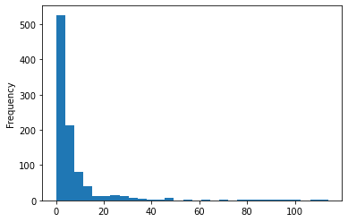

```python
SJSU_df_check['score'].plot.hist(bins=30)
```

```python
SJSU_df_check[SJSU_df_check['score'] > 10]
```

|  | title | link | author | n_comments | score | text |
| --- | --- | --- | --- | --- | --- | --- |
| 0 | Hello C'O 2025 / Transfer / Graduate / Prospec... | /r/SJSU/comments/m06ds0/hello_co_2025_transfer... | NoodlesMercury | 12 | 54 | &#x200B;\n\n[Welcome to San Jose State Univers... |
| 1 | CAMPUS BUILDING ACCESS AND TOWER CARDS | /r/SJSU/comments/q3ggay/campus_building_access... | ThePleb420 | 1 | 12 | Hello Spartans,\n\n**Starting October 4, 2021,... |
| 2 | TRANSFERS FALL 2022 CHECK YOUR PORTAL THEY REL... | /r/SJSU/comments/t3yd23/transfers_fall_2022_ch... | dablackpantha | 48 | 21 | I JUST GOT IN |
| 13 | i got all excited for no reason | /r/SJSU/comments/t358e5/i_got_all_excited_for_... | aeexy | 22 | 22 | saw the email to check mysjsu notifications an... |
| 23 | Can you guess where each of these places are o... | /r/SJSU/comments/t2b5ed/can_you_guess_where_ea... | Homicorn | 17 | 40 |  |
| ... | ... | ... | ... | ... | ... | ... |
| 937 | Not Anymore Training | /r/SJSU/comments/pub2z5/not_anymore_training/ | Scuba_Steve9002 | 15 | 25 | I just got done with the Not Anymore training ... |
| 938 | Editorial: SJSU president must come clean abou... | /r/SJSU/comments/pu2x36/editorial_sjsu_preside... | nosotros_road_sodium | 1 | 43 |  |
| 941 | Haven't lived in San Jose for long, what do yo... | /r/SJSU/comments/ptib8q/havent_lived_in_san_jo... | Kuruttta-Kyoken | 50 | 32 | I've pretty much been working out, doing class... |
| 944 | Places with reliable wired internet on campus | /r/SJSU/comments/ptg9xm/places_with_reliable_w... | MateTheNate | 7 | 13 | I’ve asked this question before but with midte... |
| 949 | I miss the ivy on Tower Hall | /r/SJSU/comments/pslq2x/i_miss_the_ivy_on_towe... | Fetty_is_the_best | 10 | 112 |  |

144 rows × 6 columns

```python
SJSU_df_check[SJSU_df_check['score'] > 20]['link'].to_list()
```

```
['/r/SJSU/comments/m06ds0/hello_co_2025_transfer_graduate_prospect_admits/',
 '/r/SJSU/comments/t3yd23/transfers_fall_2022_check_your_portal_they/',
 '/r/SJSU/comments/t358e5/i_got_all_excited_for_no_reason/',
 '/r/SJSU/comments/t2b5ed/can_you_guess_where_each_of_these_places_are_on/',
 '/r/SJSU/comments/sx9prn/to_the_people_who_take_up_2_parking_spaces_in/',
 '/r/SJSU/comments/sv92d2/csu_chancellor_joseph_castro_resigns_amid/',
 '/r/SJSU/comments/suixd6/california_students_on_college_apps/',
 '/r/SJSU/comments/sudcch/any_older_students/',
 '/r/SJSU/comments/ssgxgu/parking_as_of_1000_south_garage_totally_full_few/',
 '/r/SJSU/comments/sovkwc/sjsu_club_archery_is_recruiting_for_spring_2022/',
 '/r/SJSU/comments/snsx17/unfortunately_president_prez_has_decided_to/',
 '/r/SJSU/comments/sm5wjg/longsecret_email_warned_san_jose_state_president/',
 '/r/SJSU/comments/sk0f7n/ahaa_yes/',
 '/r/SJSU/comments/si7bu3/tower_hall_at_night/',
 '/r/SJSU/comments/shfwca/keepsjsuhybrid/',
 '/r/SJSU/comments/sh9cmr/who_else_is_annoyed_af_with_chartwells/',
 '/r/SJSU/comments/sfxpzy/do_you_guys_think_college_will_be_in_person_after/',
 '/r/SJSU/comments/sfw0t8/update_missing_wallet/',
 '/r/SJSU/comments/sew003/uc_davis_student_walkout/',
 '/r/SJSU/comments/s850wy/open_spots_in_ge_course/',
 '/r/SJSU/comments/s5y0zr/can_we_start_a_professor_appreciation_thread/',
 '/r/SJSU/comments/s53wze/sjsu_mbb_drops_to_77_as_colorado_state_defeats_us/',
 '/r/SJSU/comments/s4r20z/cult_called_epic_movement_at_sjsu/',
 '/r/SJSU/comments/s2rfr6/why_is_there_no_proteststudent_movement_against/',
 '/r/SJSU/comments/s2jbgt/rip/',
 '/r/SJSU/comments/s2fqqz/for_students_interested_in_swe_internshipsjobs/',
 '/r/SJSU/comments/s1x2kh/are_we_going_to_get_bogged_by_the_sjsu_gods_and/',
 '/r/SJSU/comments/s17en0/just_finished_constructing_my_custom_sjsu_helmet/',
 '/r/SJSU/comments/s0syll/mysjsu/',
 '/r/SJSU/comments/rz5jyf/estimated_date_for_announcement_of_spring/',
 '/r/SJSU/comments/rvdiah/teacher_still_hasnt_uploaded_grades_for_fall_2021/',
 '/r/SJSU/comments/ruk5k7/anyone_else_still_waiting_for_fall_2021_grades/',
 '/r/SJSU/comments/ru5997/just_saw_on_the_new_that_a_lot_of_campuses_are/',
 '/r/SJSU/comments/rspz2g/ridiculous_inefficiencies_of_this_school_x3/',
 '/r/SJSU/comments/rkic9a/came_across_this_on_4th_street_near_the_library/',
 '/r/SJSU/comments/rjpcqs/psa_if_you_forgot_your_stoes_you_can_go_to_the/',
 '/r/SJSU/comments/rct9kc/anyone_wants_to_join_an_online_accountability/',
 '/r/SJSU/comments/rba38t/is_anyone_elses_canvas_displaying_this_page_been/',
 '/r/SJSU/comments/ras3vy/trevor_wallace_rocking_an_sjsu_hat_in_his_new/',
 '/r/SJSU/comments/r9swpg/well_stay_off_campus_alert_from_125/',
```

[output cut: 17 more lines]

```
 '/r/SJSU/comments/qfr6y7/professor_kicked_me_out_of_zoom_class/',
 '/r/SJSU/comments/qck8l1/homecoming_2_years_ago_sjsu/',
 '/r/SJSU/comments/qbmbmy/there_is_no_way_this_is_true_right_im_a_transfer/',
 '/r/SJSU/comments/qb0dcg/psa_the_schedule_for_spring_is_up/',
 '/r/SJSU/comments/q8cw6f/hidden_secrets_kinda/',
 '/r/SJSU/comments/q7fr8s/psa_the_fastest_way_to_find_a_parking_spot_in_the/',
 '/r/SJSU/comments/q5tri8/4k_downtown_san_jose_walking_tour_binaural_sound/',
 '/r/SJSU/comments/q3fpij/san_jose_state_university_president_mary_papazian/',
 '/r/SJSU/comments/pylmor/fun_stuff_to_do_near_campus/',
 '/r/SJSU/comments/pwq9gz/losing_my_mind/',
 '/r/SJSU/comments/puqw4p/this_is_the_only_way_i_ever_do_homework_now/',
 '/r/SJSU/comments/pub2z5/not_anymore_training/',
 '/r/SJSU/comments/pu2x36/editorial_sjsu_president_must_come_clean_about/',
 '/r/SJSU/comments/ptib8q/havent_lived_in_san_jose_for_long_what_do_you/',
 '/r/SJSU/comments/pslq2x/i_miss_the_ivy_on_tower_hall/']
```

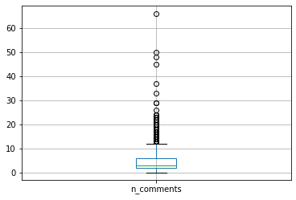

```python
SJSU_df_check.boxplot('n_comments')
```

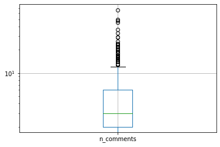

```python
import matplotlib.pyplot as plt
SJSU_df_check.boxplot('n_comments')
plt.yscale('log')
```

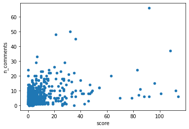

```python
SJSU_df_check.plot.scatter(x='score', y='n_comments')
```

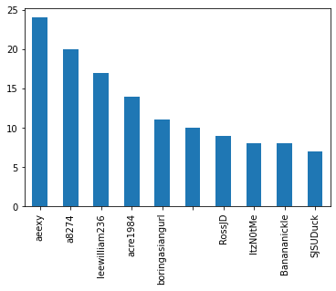

```python
SJSU_df_check['author'].value_counts()[:10].plot.bar()
```